# GR5072 Modern Data Structures_HW 8

Bolim Son

November 15, 2019

```r
# Load packages
library(httr)
library(dplyr)
```

### **1. Choose an API**

**a) Choose an API and briefly describe the type of data you can obtain from it. Note: Please do not use any of the APIs we covered in lecture (e.g. Twitter, NYTimes, Enigma, Zillow etc.).**

API of my choice is New York City Open Data, Department of Buildings(DOB) Permit Issuance. It is updated daily. Details of the data is available *[here](https://data.cityofnewyork.us/Housing-Development/DOB-Permit-Issuance/ipu4-2q9a)*

**b) Provide a link to the API documentation and**

The link to API documentation is on *[this link](https://dev.socrata.com/foundry/data.cityofnewyork.us/ipu4-2q9a)*

The API is powered by Socrata

**c) the base URL of the API you intend to use.**

```r
# Base URL

baseurl <- "https://data.cityofnewyork.us/resource/ipu4-2q9a.json"
```

### **2. Authentication**

**a) Briefly explain how the API authenticates the user.**

The API authenticates through Socrata

**b) Apply for an API key if necessary and provide the information (with relevant URL) how that can be done.**

You go to API Documentation site, which is available through *[this link](https://dev.socrata.com/foundry/data.cityofnewyork.us/ipu4-2q9a)*. Then, you scroll down the website and press “Sign up for an app token!”, and sign up for the app token.

```r
# Find R home directory
#R.home(component = "home")

# R_ENVIRON should be in "C:/PROGRA~1/R/R-36~1.1"

# Place toekn in the R environment
# usethis::edit_r_environ()

# App token for https://data.cityofnewyork.us/
```

App token name is “NYC_APP_TOKEN”, secret token is “NYC_SECRET_TOKEN”

### **3. Send a Simple GET request**

1. Execute a simple GET request to obtain a small amount of data from the API. Describe a few query parameters and add them to the query. If you have a choice of the output the API returns (e.g. XML or JSON), I suggest to choose JSON because it easier to work with. Your output here should include the code for the GET request, including the query parameters.

```r
# Use the API key
# Make a simple GET request with query parameters
# Manhattan only, 5000 rows only

sample <- GET(baseurl, query = list("borough" = "MANHATTAN", "$limit" = "5000", "$$app_token" =  Sys.getenv("NYC_APP_TOKEN")))

# Check structure
str(sample, max.level = 1)
```

```
## List of 10
##  $ url        : chr "https://data.cityofnewyork.us/resource/ipu4-2q9a.json?borough=MANHATTAN&%24limit=5000&%24%24app_token=kNkN54bP7"| __truncated__
##  $ status_code: int 200
##  $ headers    :List of 19
##   ..- attr(*, "class")= chr [1:2] "insensitive" "list"
##  $ all_headers:List of 1
##  $ cookies    :'data.frame': 0 obs. of  7 variables:
##  $ content    : raw [1:6690962] 5b 7b 22 62 ...
##  $ date       : POSIXct[1:1], format: "2019-11-18 16:03:06"
##  $ times      : Named num [1:6] 0 0.0245 0.0451 0.0777 0.2528 ...
##   ..- attr(*, "names")= chr [1:6] "redirect" "namelookup" "connect" "pretransfer" ...
##  $ request    :List of 7
##   ..- attr(*, "class")= chr "request"
##  $ handle     :Class 'curl_handle' <externalptr>
##  - attr(*, "class")= chr "response"
```

2. Check the status of the request (using http_status).

```r
# Check status
http_status(sample)
```

```
## $category
## [1] "Success"
##
## $reason
## [1] "OK"
##
## $message
## [1] "Success: (200) OK"
```

3. Check the type of the response (e.g. XML, JSON, csv using http_type).

```r
# Check type
http_type(sample)
```

```
## [1] "application/json"
```

### **4. Parse the response and Create a dataset**

1. Take the response returned by the API and turn it into a useful R object (e.g. a list, vector, or data frame). Show the code how this is done.

```r
# Change it to a useful R object
sample_r <- content(sample)

# See structure of sample_r
typeof(sample_r)
```

```
## [1] "list"
```

```r
# Change it to a dataframe
# Because it is a list, use purrr package to change it to a data.frame
library(purrr)

# Change to a data.frame using map_df and `[` function
sample_r_df <- sample_r %>% map_df(., `[`)

# Explore the data.frame
dim(sample_r_df)
```

```
## [1] 5000   59
```

```r
# See the first few contents
head(sample_r_df)
```

| borough | bin__ | house__ | street_name | job__ | job_doc___ | job_type | self_cert | block | lot | community_board | zip_code | bldg_type | residential | work_type | permit_status | filing_status | permit_type | permit_sequence__ | filing_date | issuance_date | expiration_date | job_start_date | permittee_s_first_name | permittee_s_last_name | permittee_s_business_name | permittee_s_phone__ | permittee_s_license_type | permittee_s_license__ | owner_s_business_type | … |
| --- | --- | --- | --- | --- | --- | --- | --- | --- | --- | --- | --- | --- | --- | --- | --- | --- | --- | --- | --- | --- | --- | --- | --- | --- | --- | --- | --- | --- | --- | --- |
| MANHATTAN | 1062333 | 618 | WEST 142 STREET | 140874114 | 01 | A3 | Y | 02088 | 00106 | 109 | 10031 | 2 | YES | OT | ISSUED | INITIAL | AL | 01 | 2019-11-15T00:00:00.000 | 2019-11-15T00:00:00.000 | 2020-02-03T00:00:00.000 | 2019-11-15T00:00:00.000 | JASPREET | SINGH | S & J CONSTRUCTION SERVIC | 7184967251 | GC | 0616952 | INDIVIDUAL | … |
| MANHATTAN | 1008113 | 37 | CHARLTON STREET | 123711572 | 01 | A2 | N | 00519 | 00063 | 102 | 10014 | 1 | YES | OT | IN PROCESS | RENEWAL | EW | 02 | 2019-11-15T00:00:00.000 | NA | NA | 2019-10-03T00:00:00.000 | NA | NA | NA | NA | NA | NA | PARTNERSHIP | … |
| MANHATTAN | 1016079 | 79 | 5TH AVE | 123742726 | 01 | A2 | Y | 00843 | 00045 | 105 | 10003 | 2 | NA | OT | ISSUED | INITIAL | EW | 01 | 2019-11-15T00:00:00.000 | 2019-11-15T00:00:00.000 | 2019-12-19T00:00:00.000 | 2019-11-15T00:00:00.000 | ROBERT | FRANKENBERRY | ICON INTERIORS INC | 2126759180 | GC | 0007715 | PARTNERSHIP | … |
| MANHATTAN | 1002817 | 399 | WASHINGTON STREET | 123732158 | 01 | A2 | N | 00217 | 00011 | 101 | 10013 | 2 | YES | OT | IN PROCESS | INITIAL | EW | 01 | 2019-11-15T00:00:00.000 | NA | NA | 2019-11-15T00:00:00.000 | NA | NA | NA | NA | NA | NA | CONDO/CO-OP | … |
| MANHATTAN | 1034196 | 1114 | AVENUE OF THE AMERICAS | 123757924 | 02 | A2 | Y | 01258 | 00009 | 105 | 10036 | 2 | NA | PL | ISSUED | INITIAL | PL | 01 | 2019-11-15T00:00:00.000 | 2019-11-15T00:00:00.000 | 2020-11-14T00:00:00.000 | 2019-11-15T00:00:00.000 | VINCENT | GAMBA | OLYMPIC PLBG & HTG SVC IN | 7185284001 | MP | 0001580 | PARTNERSHIP | … |
| MANHATTAN | 1009294 | 12 | EAST 12 STREET | 123489947 | 01 | A2 | Y | 00569 | 07501 | 102 | 10003 | 2 | YES | PL | ISSUED | INITIAL | PL | 01 | 2019-11-15T00:00:00.000 | 2019-11-15T00:00:00.000 | 2020-11-14T00:00:00.000 | 2019-11-15T00:00:00.000 | ALESSANDRO | DEMARINIS | DEMAR PLUMBING CORP | 2126149717 | MP | 0001549 | CORPORATION | … |

2. Using the API, create a dataset (in data frame format) for multiple records. I’d say a sample size greater than 100 is sufficient for the example but feel free to get more data if you feel ambitious and the API allows you to do that fairly easily. The dataset can include only a small subset of the returned data. Just choose some interesting features. There is no need to be inclusive here.

```r
# Create a dataset for multiple records
# Filter only residential buildings
residential_df <- sample_r_df %>%
  filter(residential == "YES") %>%
# Choose street, work type, filing status, job start date, expiration date, and owner's business type
  select(street_name, filing_status, job_start_date, expiration_date, owner_s_business_type) %>%
# Change date columns as dates
  mutate(job_start_date = as.Date(job_start_date), expiration_date = as.Date(expiration_date))
```

3. Provide some summary statistics of the data. Include the data frame in a .RDS file (using saveRDS) called data.rds with your submission for the grader.

```r
# See some basic information for residential_df
summary(residential_df)
```

```
##  street_name        filing_status      job_start_date
##  Length:2384        Length:2384        Min.   :1991-05-21
##  Class :character   Class :character   1st Qu.:2018-05-22
##  Mode  :character   Mode  :character   Median :2019-09-20
##                                        Mean   :2018-06-20
##                                        3rd Qu.:2019-10-30
##                                        Max.   :2019-11-17
##
##  expiration_date      owner_s_business_type
##  Min.   :1992-12-27   Length:2384
##  1st Qu.:2020-04-09   Class :character
##  Median :2020-08-01   Mode  :character
##  Mean   :2020-04-24
##  3rd Qu.:2020-10-22
##  Max.   :2020-11-23
##  NA's   :78
```

Exploratory data analysis for residential_df:

```r
library(dplyr)
library(ggplot2)

# Top 10 streets for residential permit issuance
residential_df %>%
  group_by(street_name) %>%
  summarise(streets = n()) %>%
  arrange(desc(streets)) %>%
  head(., 10) %>%
  labs(title = "Top 10 popular streets for residental permit issuance")
```

```
## [[1]]
## # A tibble: 10 x 2
##    street_name        streets
##    <chr>                <int>
##  1 BROADWAY               107
##  2 WEST 72ND STREET        52
##  3 PARK AVENUE             51
##  4 GREAT JONES STREET      49
##  5 WEST END AVENUE         35
##  6 RIVERSIDE DRIVE         33
##  7 FIFTH AVENUE            23
##  8 MADISON AVENUE          23
##  9 CENTRAL PARK WEST       22
## 10 EAST 13TH STREET        22
##
## $title
## [1] "Top 10 popular streets for residental permit issuance"
##
## attr(,"class")
## [1] "labels"
```

```r
# Filing status
residential_df %>%
  group_by(filing_status) %>% # Group by filing status
  summarise(count = n()) %>% # Count for each group
  mutate(percentage = round(count/sum(count) * 100,digits = 2)) %>% # Calculate percentages
  select(filing_status, count, percentage) # Select relevant columns
```

| filing_status | count | percentage |
| --- | --- | --- |
| INITIAL | 1159 | 48.62 |
| RENEWAL | 1225 | 51.38 |

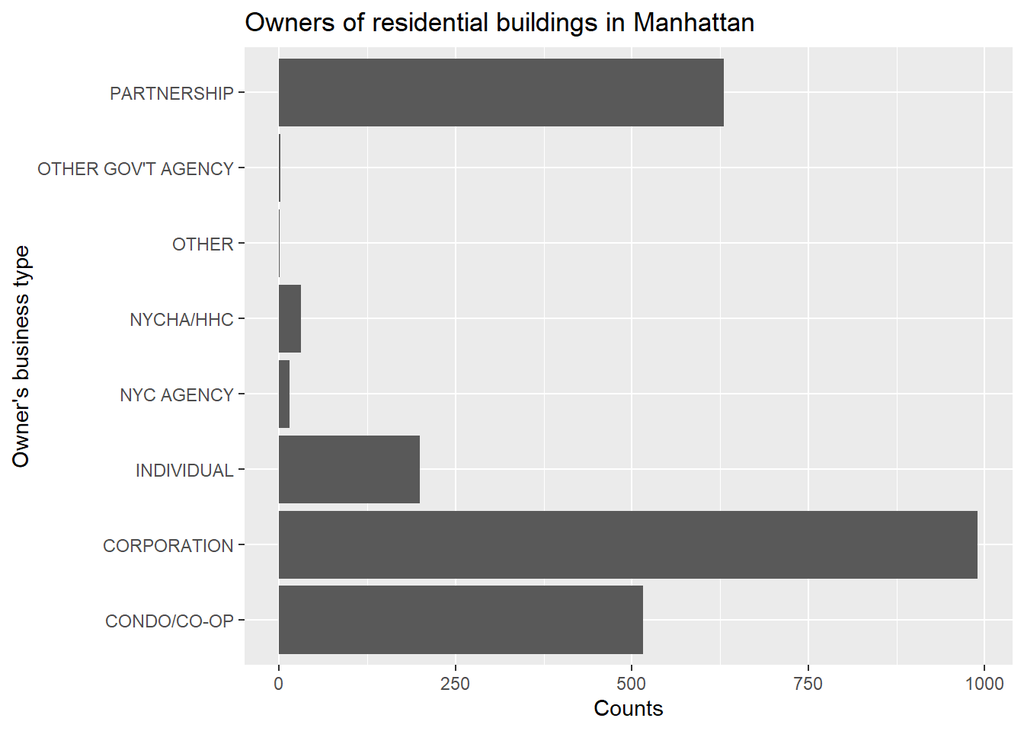

```r
# Who owns residential buildings in Manhattan
residential_df %>%
  group_by(owner_s_business_type) %>%
  summarise(count = n()) %>%
  ggplot(.) + # Create visualization
  geom_col(aes(x = owner_s_business_type, y = count)) +
  labs(title = "Owners of residential buildings in Manhattan", x = "Owner's business type", y = "Counts") +
  coord_flip()
```

```r
# How long does it take from start to expiration on average?
mean(residential_df$expiration_date - residential_df$job_start_date, na.rm = TRUE)
```

```
## Time difference of 673.7923 days
```

### **5. API Client**

Lastly, let’s try to wrap the code from the previous sections into a simple API client function. For example, in the ZillowR package, the command GetSearchResults() can be called with the following command

GetSearchResults(address = ‘2114 Bigelow Ave’, citystatezip = ‘Seattle, WA’)

For your API function, try to create a simple function that does the following things:

- allows to user to specify some smallish set of query parameters (from Q.3a)
- run a GET request with these parameters
- check the status of the request the server returns and inform the user of any errors (from Q.3b)
- parse the response and return a R object to the user of the function. You can choose whether returning a list (from Q.4a) or a data frame (from Q.4b) is best.

Note: There is no need to make this into an R package here. A simple function is sufficient.

For the grader, please provide the following output.

1. Your full function to access the API functionality. Set some sensible default values for the query parameters.

```r
# API client function "nycDOBdata"

# Default parameters set for borough (MANHATTAN), permit_status (ISSUED), filing_status (RENEWAL)

nycDOBdata <- function(borough = "MANHATTAN", permit_status = "ISSUED", filing_status = "RENEWAL"){
# Set base url
    baseurl <- "https://data.cityofnewyork.us/resource/ipu4-2q9a.json"
# Check if query parameters are set correctly

# Check borough
boroughs <- c("MANHATTAN", "BRONX", "BROOKLYN", "QUEENS","STATEN ISLAND")

    if(borough %in% boroughs == FALSE){
    stop("Must enter only one of NYC boroughs as texts. Boroughs are MANHATTAN, BRONX, BROOKLYN, QUEENS, STATEN ISLAND", call. = FALSE)
  }

# Check permit status
permits <- c("ISSUED", "IN PROCESS", "RE-ISSUED", NA)
  if(permit_status %in% permits == FALSE){
    stop("Must enter only one of permit status as texts. Permit status are ISSUED, IN PROCESS, or RE-ISSUED")
  }

# Check filing status
filings <- c("INITIAL", "RENEWAL")
  if(filing_status %in% filings == FALSE){
    stop("Must enter one of INITIAL or RENEWAL for filing status")
  }

# Clear query errors, do GET request
  else{
# GET request, limited to 200 rows
  api_request <- GET(baseurl, query = list("borough" = borough, "permit_status" = permit_status, "filing_status" = filing_status, "$limit" = "200"))
  }

  # Check status
  if(http_status(api_request)$category != "Success"){
    stop("API has an error", call. = FALSE)
  }

  # Check data type to be json
  if(http_type(api_request) != "application/json"){
    stop("API should return json", call. = FALSE)
  }

# Return R object from requested API
  api_content <- content(api_request)

# Change it to a data.frame
  api_df <- purrr::map_df(api_content, `[`)


}
```

2. The object your function returns for the default values. Please save this output object to api_client_output.RDS and include it with your submission.

```r
# Returns for default values
api_client_output <- nycDOBdata()

# Save as RDS file
saveRDS(api_client_output, file = "api_client_output.rds")
```